# Optimal Treatment Analysis

## Outcome Variable

**Outcome Variable:** haz

## Predictor Variables

**Intervention Variable:** month

**Adjustment Set:**

unadjusted

## Stratifying Variables

The analysis was stratified on these variable(s):

- agecat
- studyid
- country

## Data Summary

| agecat | studyid | country | month | n_cell | n |
| --- | --- | --- | --- | --- | --- |
| Birth | ki0047075b-MAL-ED | BANGLADESH | 1 | 19 | 257 |
| Birth | ki0047075b-MAL-ED | BANGLADESH | 2 | 24 | 257 |
| Birth | ki0047075b-MAL-ED | BANGLADESH | 3 | 28 | 257 |
| Birth | ki0047075b-MAL-ED | BANGLADESH | 4 | 21 | 257 |
| Birth | ki0047075b-MAL-ED | BANGLADESH | 5 | 21 | 257 |
| Birth | ki0047075b-MAL-ED | BANGLADESH | 6 | 9 | 257 |
| Birth | ki0047075b-MAL-ED | BANGLADESH | 7 | 22 | 257 |
| Birth | ki0047075b-MAL-ED | BANGLADESH | 8 | 25 | 257 |
| Birth | ki0047075b-MAL-ED | BANGLADESH | 9 | 22 | 257 |
| Birth | ki0047075b-MAL-ED | BANGLADESH | 10 | 24 | 257 |
| Birth | ki0047075b-MAL-ED | BANGLADESH | 11 | 15 | 257 |
| Birth | ki0047075b-MAL-ED | BANGLADESH | 12 | 27 | 257 |
| Birth | ki0047075b-MAL-ED | BRAZIL | 1 | 9 | 191 |
| Birth | ki0047075b-MAL-ED | BRAZIL | 2 | 21 | 191 |
| Birth | ki0047075b-MAL-ED | BRAZIL | 3 | 18 | 191 |
| Birth | ki0047075b-MAL-ED | BRAZIL | 4 | 8 | 191 |
| Birth | ki0047075b-MAL-ED | BRAZIL | 5 | 19 | 191 |
| Birth | ki0047075b-MAL-ED | BRAZIL | 6 | 7 | 191 |
| Birth | ki0047075b-MAL-ED | BRAZIL | 7 | 17 | 191 |
| Birth | ki0047075b-MAL-ED | BRAZIL | 8 | 18 | 191 |
| Birth | ki0047075b-MAL-ED | BRAZIL | 9 | 28 | 191 |
| Birth | ki0047075b-MAL-ED | BRAZIL | 10 | 18 | 191 |
| Birth | ki0047075b-MAL-ED | BRAZIL | 11 | 15 | 191 |
| Birth | ki0047075b-MAL-ED | BRAZIL | 12 | 13 | 191 |
| Birth | ki0047075b-MAL-ED | INDIA | 1 | 16 | 206 |
| Birth | ki0047075b-MAL-ED | INDIA | 2 | 16 | 206 |
| Birth | ki0047075b-MAL-ED | INDIA | 3 | 20 | 206 |
| Birth | ki0047075b-MAL-ED | INDIA | 4 | 15 | 206 |
| Birth | ki0047075b-MAL-ED | INDIA | 5 | 7 | 206 |
| Birth | ki0047075b-MAL-ED | INDIA | 6 | 17 | 206 |

[output cut: 798 more lines]

The following strata were considered:

- agecat: 24 months, studyid: ki0047075b-MAL-ED, country: BANGLADESH
- agecat: 24 months, studyid: ki0047075b-MAL-ED, country: BRAZIL
- agecat: 24 months, studyid: ki0047075b-MAL-ED, country: INDIA
- agecat: 24 months, studyid: ki0047075b-MAL-ED, country: NEPAL
- agecat: 24 months, studyid: ki0047075b-MAL-ED, country: PERU
- agecat: 24 months, studyid: ki0047075b-MAL-ED, country: SOUTH AFRICA
- agecat: 24 months, studyid: ki0047075b-MAL-ED, country: TANZANIA, UNITED REPUBLIC OF
- agecat: 24 months, studyid: ki1000108-CMC-V-BCS-2002, country: INDIA
- agecat: 24 months, studyid: ki1000108-IRC, country: INDIA
- agecat: 24 months, studyid: ki1017093-NIH-Birth, country: BANGLADESH
- agecat: 24 months, studyid: ki1066203-TanzaniaChild2, country: TANZANIA, UNITED REPUBLIC OF
- agecat: 24 months, studyid: ki1113344-GMS-Nepal, country: NEPAL
- agecat: 24 months, studyid: ki1114097-CMIN, country: BANGLADESH
- agecat: 24 months, studyid: ki1114097-CMIN, country: GUINEA-BISSAU
- agecat: 24 months, studyid: ki1114097-CMIN, country: PERU
- agecat: 24 months, studyid: ki1114097-CONTENT, country: PERU
- agecat: 24 months, studyid: ki1119695-PROBIT, country: BELARUS
- agecat: 24 months, studyid: ki1126311-ZVITAMBO, country: ZIMBABWE
- agecat: 24 months, studyid: ki1148112-LCNI-5, country: MALAWI
- agecat: 24 months, studyid: kiGH5241-JiVitA-3, country: BANGLADESH
- agecat: 24 months, studyid: kiGH5241-JiVitA-4, country: BANGLADESH
- agecat: 6 months, studyid: ki0047075b-MAL-ED, country: BANGLADESH
- agecat: 6 months, studyid: ki0047075b-MAL-ED, country: BRAZIL
- agecat: 6 months, studyid: ki0047075b-MAL-ED, country: INDIA
- agecat: 6 months, studyid: ki0047075b-MAL-ED, country: NEPAL
- agecat: 6 months, studyid: ki0047075b-MAL-ED, country: PERU
- agecat: 6 months, studyid: ki0047075b-MAL-ED, country: SOUTH AFRICA
- agecat: 6 months, studyid: ki0047075b-MAL-ED, country: TANZANIA, UNITED REPUBLIC OF
- agecat: 6 months, studyid: ki1000108-CMC-V-BCS-2002, country: INDIA
- agecat: 6 months, studyid: ki1000108-IRC, country: INDIA
- agecat: 6 months, studyid: ki1000109-EE, country: PAKISTAN
- agecat: 6 months, studyid: ki1000109-ResPak, country: PAKISTAN
- agecat: 6 months, studyid: ki1000304b-SAS-CompFeed, country: INDIA
- agecat: 6 months, studyid: ki1000304b-SAS-FoodSuppl, country: INDIA
- agecat: 6 months, studyid: ki1017093-NIH-Birth, country: BANGLADESH
- agecat: 6 months, studyid: ki1066203-TanzaniaChild2, country: TANZANIA, UNITED REPUBLIC OF
- agecat: 6 months, studyid: ki1112895-Guatemala BSC, country: GUATEMALA
- agecat: 6 months, studyid: ki1113344-GMS-Nepal, country: NEPAL
- agecat: 6 months, studyid: ki1114097-CMIN, country: BANGLADESH
- agecat: 6 months, studyid: ki1114097-CMIN, country: BRAZIL
- agecat: 6 months, studyid: ki1114097-CMIN, country: GUINEA-BISSAU
- agecat: 6 months, studyid: ki1114097-CMIN, country: PERU
- agecat: 6 months, studyid: ki1114097-CONTENT, country: PERU
- agecat: 6 months, studyid: ki1119695-PROBIT, country: BELARUS
- agecat: 6 months, studyid: ki1126311-ZVITAMBO, country: ZIMBABWE
- agecat: 6 months, studyid: ki1148112-LCNI-5, country: MALAWI
- agecat: 6 months, studyid: kiGH5241-JiVitA-3, country: BANGLADESH
- agecat: 6 months, studyid: kiGH5241-JiVitA-4, country: BANGLADESH
- agecat: Birth, studyid: ki0047075b-MAL-ED, country: BANGLADESH
- agecat: Birth, studyid: ki0047075b-MAL-ED, country: BRAZIL
- agecat: Birth, studyid: ki0047075b-MAL-ED, country: INDIA
- agecat: Birth, studyid: ki0047075b-MAL-ED, country: NEPAL
- agecat: Birth, studyid: ki0047075b-MAL-ED, country: PERU
- agecat: Birth, studyid: ki0047075b-MAL-ED, country: SOUTH AFRICA
- agecat: Birth, studyid: ki0047075b-MAL-ED, country: TANZANIA, UNITED REPUBLIC OF
- agecat: Birth, studyid: ki1000108-CMC-V-BCS-2002, country: INDIA
- agecat: Birth, studyid: ki1000108-IRC, country: INDIA
- agecat: Birth, studyid: ki1000109-EE, country: PAKISTAN
- agecat: Birth, studyid: ki1000109-ResPak, country: PAKISTAN
- agecat: Birth, studyid: ki1000304b-SAS-CompFeed, country: INDIA
- agecat: Birth, studyid: ki1017093-NIH-Birth, country: BANGLADESH
- agecat: Birth, studyid: ki1114097-CMIN, country: BANGLADESH
- agecat: Birth, studyid: ki1114097-CMIN, country: BRAZIL
- agecat: Birth, studyid: ki1114097-CMIN, country: PERU
- agecat: Birth, studyid: ki1114097-CONTENT, country: PERU
- agecat: Birth, studyid: ki1119695-PROBIT, country: BELARUS
- agecat: Birth, studyid: ki1126311-ZVITAMBO, country: ZIMBABWE
- agecat: Birth, studyid: kiGH5241-JiVitA-3, country: BANGLADESH
- agecat: Birth, studyid: kiGH5241-JiVitA-4, country: BANGLADESH

### Dropped Strata

Some strata were dropped due to rare outcomes:

- agecat: Birth, studyid: ki0047075b-MAL-ED, country: TANZANIA, UNITED REPUBLIC OF
- agecat: Birth, studyid: ki1000108-CMC-V-BCS-2002, country: INDIA
- agecat: Birth, studyid: ki1000109-EE, country: PAKISTAN
- agecat: Birth, studyid: ki1000109-ResPak, country: PAKISTAN
- agecat: Birth, studyid: ki1017093-NIH-Birth, country: BANGLADESH
- agecat: Birth, studyid: ki1114097-CMIN, country: BANGLADESH
- agecat: Birth, studyid: ki1114097-CMIN, country: BRAZIL
- agecat: Birth, studyid: ki1114097-CMIN, country: PERU
- agecat: Birth, studyid: ki1114097-CONTENT, country: PERU
- agecat: Birth, studyid: kiGH5241-JiVitA-4, country: BANGLADESH
- agecat: 6 months, studyid: ki1000109-EE, country: PAKISTAN
- agecat: 6 months, studyid: ki1000109-ResPak, country: PAKISTAN
- agecat: 6 months, studyid: ki1000304b-SAS-FoodSuppl, country: INDIA
- agecat: 6 months, studyid: ki1113344-GMS-Nepal, country: NEPAL
- agecat: 6 months, studyid: ki1114097-CMIN, country: BANGLADESH
- agecat: 6 months, studyid: ki1114097-CMIN, country: BRAZIL
- agecat: 24 months, studyid: ki1066203-TanzaniaChild2, country: TANZANIA, UNITED REPUBLIC OF
- agecat: 24 months, studyid: ki1113344-GMS-Nepal, country: NEPAL
- agecat: 24 months, studyid: ki1114097-CMIN, country: BANGLADESH
- agecat: 24 months, studyid: ki1114097-CONTENT, country: PERU
- agecat: 24 months, studyid: ki1126311-ZVITAMBO, country: ZIMBABWE

## Methods Detail

We’re interested in the causal parameters $E[Y_a]$ for all values of $a \in \mathcal{A}$. These parameters represent the mean outcome if, possibly contrary to fact, we intervened to set all units to have $A=a$. Under the randomization and positivity assumptions, these are identified by the statistical parameters $\psi_a=E_W[E_{Y|A,W}(Y|A=a,W)]$. In addition, we’re interested in the mean of $Y$, $E[Y]$ under no intervention (the observed mean). We will estimate these parameters by using SuperLearner to fit the relevant likelihood factors – $E_{Y|A,W}(Y|A=a,W)$ and $p(A=a|W)$, and then updating our likelihood fit using a joint TMLE.

For unadjusted analyses ($W=\{\}$), initial likelihoods were estimated using Lrnr_glm to estimate the simple $E(Y|A)$ and Lrnr_mean to estimate $p(A)$. For adjusted analyses, a small library containing Lrnr_glmnet, Lrnr_xgboost, and Lrnr_mean was used.

# Results Detail

## Results Plots

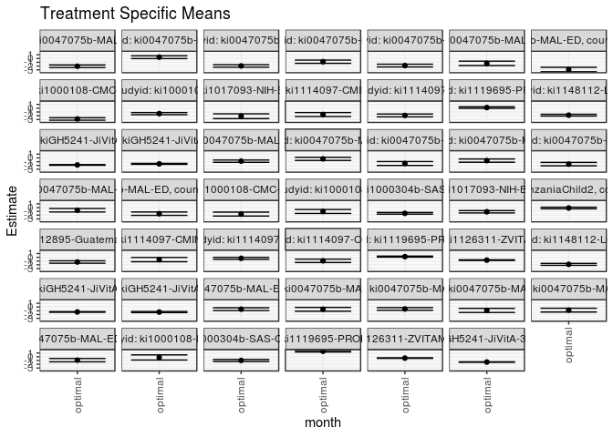

## Results Table

### Parameter: TSM

| agecat | studyid | country | intervention_level | baseline_level | estimate | ci_lower | ci_upper |
| --- | --- | --- | --- | --- | --- | --- | --- |
| Birth | ki0047075b-MAL-ED | BANGLADESH | optimal | observed | -0.5776310 | -0.9518471 | -0.2034148 |
| Birth | ki0047075b-MAL-ED | BRAZIL | optimal | observed | -0.6044459 | -1.1009300 | -0.1079618 |
| Birth | ki0047075b-MAL-ED | INDIA | optimal | observed | -0.5108045 | -0.8677717 | -0.1538373 |
| Birth | ki0047075b-MAL-ED | NEPAL | optimal | observed | -0.9045629 | -1.4497698 | -0.3593560 |
| Birth | ki0047075b-MAL-ED | PERU | optimal | observed | -0.8237843 | -1.3275356 | -0.3200329 |
| Birth | ki0047075b-MAL-ED | SOUTH AFRICA | optimal | observed | -0.9070689 | -1.3503576 | -0.4637801 |
| Birth | ki1000108-IRC | INDIA | optimal | observed | -0.1906475 | -0.8678532 | 0.4865583 |
| Birth | ki1000304b-SAS-CompFeed | INDIA | optimal | observed | -0.9870283 | -1.2667816 | -0.7072750 |
| Birth | ki1119695-PROBIT | BELARUS | optimal | observed | 1.4573775 | 1.2536471 | 1.6611079 |
| Birth | ki1126311-ZVITAMBO | ZIMBABWE | optimal | observed | -0.3626805 | -0.4286122 | -0.2967488 |
| Birth | kiGH5241-JiVitA-3 | BANGLADESH | optimal | observed | -1.4113622 | -1.4715907 | -1.3511338 |
| 6 months | ki0047075b-MAL-ED | BANGLADESH | optimal | observed | -0.8637627 | -1.1715038 | -0.5560216 |
| 6 months | ki0047075b-MAL-ED | BRAZIL | optimal | observed | -0.2504471 | -0.6669840 | 0.1660898 |
| 6 months | ki0047075b-MAL-ED | INDIA | optimal | observed | -1.4811944 | -1.9985157 | -0.9638731 |
| 6 months | ki0047075b-MAL-ED | NEPAL | optimal | observed | -0.7161552 | -1.1489100 | -0.2834004 |
| 6 months | ki0047075b-MAL-ED | PERU | optimal | observed | -1.6447508 | -2.0964964 | -1.1930053 |
| 6 months | ki0047075b-MAL-ED | SOUTH AFRICA | optimal | observed | -0.6967900 | -1.1533855 | -0.2401945 |
| 6 months | ki0047075b-MAL-ED | TANZANIA, UNITED REPUBLIC OF | optimal | observed | -1.6134128 | -2.0604942 | -1.1663314 |
| 6 months | ki1000108-CMC-V-BCS-2002 | INDIA | optimal | observed | -1.7181813 | -2.2386062 | -1.1977564 |
| 6 months | ki1000108-IRC | INDIA | optimal | observed | -1.0197338 | -1.5390813 | -0.5003863 |
| 6 months | ki1000304b-SAS-CompFeed | INDIA | optimal | observed | -1.5182755 | -1.7407625 | -1.2957885 |
| 6 months | ki1017093-NIH-Birth | BANGLADESH | optimal | observed | -1.0971202 | -1.4094571 | -0.7847833 |
| 6 months | ki1066203-TanzaniaChild2 | TANZANIA, UNITED REPUBLIC OF | optimal | observed | -0.1014485 | -0.3135576 | 0.1106607 |
| 6 months | ki1112895-Guatemala BSC | GUATEMALA | optimal | observed | -1.2395600 | -1.5656338 | -0.9134862 |
| 6 months | ki1114097-CMIN | GUINEA-BISSAU | optimal | observed | -0.6008753 | -1.1659409 | -0.0358097 |
| 6 months | ki1114097-CMIN | PERU | optimal | observed | -0.2674420 | -0.5312975 | -0.0035865 |
| 6 months | ki1114097-CONTENT | PERU | optimal | observed | -0.9301981 | -1.3758107 | -0.4845856 |
| 6 months | ki1119695-PROBIT | BELARUS | optimal | observed | 0.1857754 | 0.0560449 | 0.3155058 |
| 6 months | ki1126311-ZVITAMBO | ZIMBABWE | optimal | observed | -0.7490793 | -0.8365469 | -0.6616118 |
| 6 months | ki1148112-LCNI-5 | MALAWI | optimal | observed | -1.8629339 | -2.1198989 | -1.6059690 |
| 6 months | kiGH5241-JiVitA-3 | BANGLADESH | optimal | observed | -1.3042055 | -1.3762581 | -1.2321528 |
| 6 months | kiGH5241-JiVitA-4 | BANGLADESH | optimal | observed | -1.3366209 | -1.4820330 | -1.1912087 |
| 24 months | ki0047075b-MAL-ED | BANGLADESH | optimal | observed | -2.0578638 | -2.4074940 | -1.7082336 |
| 24 months | ki0047075b-MAL-ED | BRAZIL | optimal | observed | 0.3503031 | -0.0158345 | 0.7164406 |
| 24 months | ki0047075b-MAL-ED | INDIA | optimal | observed | -1.9691182 | -2.3063080 | -1.6319284 |
| 24 months | ki0047075b-MAL-ED | NEPAL | optimal | observed | -0.8563816 | -1.2789466 | -0.4338166 |
| 24 months | ki0047075b-MAL-ED | PERU | optimal | observed | -1.8722249 | -2.2419317 | -1.5025180 |
| 24 months | ki0047075b-MAL-ED | SOUTH AFRICA | optimal | observed | -1.2881004 | -1.8698608 | -0.7063399 |
| 24 months | ki0047075b-MAL-ED | TANZANIA, UNITED REPUBLIC OF | optimal | observed | -2.9263617 | -3.5157816 | -2.3369418 |
| 24 months | ki1000108-CMC-V-BCS-2002 | INDIA | optimal | observed | -2.8541197 | -3.1784406 | -2.5297989 |
| 24 months | ki1000108-IRC | INDIA | optimal | observed | -1.4349200 | -1.7114754 | -1.1583645 |
| 24 months | ki1017093-NIH-Birth | BANGLADESH | optimal | observed | -2.1236304 | -2.7536565 | -1.4936043 |
| 24 months | ki1114097-CMIN | GUINEA-BISSAU | optimal | observed | -1.6791362 | -2.2005576 | -1.1577149 |
| 24 months | ki1114097-CMIN | PERU | optimal | observed | -1.9168024 | -2.2942566 | -1.5393482 |
| 24 months | ki1119695-PROBIT | BELARUS | optimal | observed | 0.1652435 | -0.0466260 | 0.3771130 |
| 24 months | ki1148112-LCNI-5 | MALAWI | optimal | observed | -1.8433509 | -2.0814825 | -1.6052193 |
| 24 months | kiGH5241-JiVitA-3 | BANGLADESH | optimal | observed | -1.8644897 | -1.9552078 | -1.7737717 |
| 24 months | kiGH5241-JiVitA-4 | BANGLADESH | optimal | observed | -1.5760367 | -1.6992497 | -1.4528237 |

### Parameter: E(Y)

| agecat | studyid | country | intervention_level | baseline_level | estimate | ci_lower | ci_upper |
| --- | --- | --- | --- | --- | --- | --- | --- |
| Birth | ki0047075b-MAL-ED | BANGLADESH | observed | observed | -1.0843969 | -1.2100768 | -0.9587169 |
| Birth | ki0047075b-MAL-ED | BRAZIL | observed | observed | -0.7609424 | -0.9178311 | -0.6040538 |
| Birth | ki0047075b-MAL-ED | INDIA | observed | observed | -1.0106311 | -1.1499962 | -0.8712660 |
| Birth | ki0047075b-MAL-ED | NEPAL | observed | observed | -0.7089017 | -0.8656064 | -0.5521971 |
| Birth | ki0047075b-MAL-ED | PERU | observed | observed | -0.9322300 | -1.0461262 | -0.8183337 |
| Birth | ki0047075b-MAL-ED | SOUTH AFRICA | observed | observed | -0.7266031 | -0.8549719 | -0.5982342 |
| Birth | ki1000108-IRC | INDIA | observed | observed | -0.3080412 | -0.4687931 | -0.1472894 |
| Birth | ki1000304b-SAS-CompFeed | INDIA | observed | observed | -1.3946524 | -1.5833612 | -1.2059436 |
| Birth | ki1119695-PROBIT | BELARUS | observed | observed | 1.3254775 | 1.1669293 | 1.4840258 |
| Birth | ki1126311-ZVITAMBO | ZIMBABWE | observed | observed | -0.5011749 | -0.5217748 | -0.4805751 |
| Birth | kiGH5241-JiVitA-3 | BANGLADESH | observed | observed | -1.5747407 | -1.5944667 | -1.5550147 |
| 6 months | ki0047075b-MAL-ED | BANGLADESH | observed | observed | -1.2056777 | -1.3231497 | -1.0882058 |
| 6 months | ki0047075b-MAL-ED | BRAZIL | observed | observed | 0.0510207 | -0.0930194 | 0.1950608 |
| 6 months | ki0047075b-MAL-ED | INDIA | observed | observed | -1.2203672 | -1.3387619 | -1.1019726 |
| 6 months | ki0047075b-MAL-ED | NEPAL | observed | observed | -0.5610593 | -0.6737915 | -0.4483272 |
| 6 months | ki0047075b-MAL-ED | PERU | observed | observed | -1.3268010 | -1.4351217 | -1.2184802 |
| 6 months | ki0047075b-MAL-ED | SOUTH AFRICA | observed | observed | -1.0633760 | -1.1911088 | -0.9356432 |
| 6 months | ki0047075b-MAL-ED | TANZANIA, UNITED REPUBLIC OF | observed | observed | -1.3601215 | -1.4821830 | -1.2380600 |
| 6 months | ki1000108-CMC-V-BCS-2002 | INDIA | observed | observed | -1.4234508 | -1.5645974 | -1.2823042 |
| 6 months | ki1000108-IRC | INDIA | observed | observed | -1.2344062 | -1.3658524 | -1.1029600 |
| 6 months | ki1000304b-SAS-CompFeed | INDIA | observed | observed | -1.4018563 | -1.4810585 | -1.3226541 |
| 6 months | ki1017093-NIH-Birth | BANGLADESH | observed | observed | -1.4073821 | -1.4960598 | -1.3187043 |
| 6 months | ki1066203-TanzaniaChild2 | TANZANIA, UNITED REPUBLIC OF | observed | observed | -0.5434389 | -0.5924056 | -0.4944722 |
| 6 months | ki1112895-Guatemala BSC | GUATEMALA | observed | observed | -1.5619008 | -1.6727702 | -1.4510313 |
| 6 months | ki1114097-CMIN | GUINEA-BISSAU | observed | observed | -0.6075943 | -0.6832781 | -0.5319106 |
| 6 months | ki1114097-CMIN | PERU | observed | observed | -0.5132548 | -0.5926717 | -0.4338380 |
| 6 months | ki1114097-CONTENT | PERU | observed | observed | -0.3139217 | -0.4868486 | -0.1409948 |
| 6 months | ki1119695-PROBIT | BELARUS | observed | observed | 0.1069986 | 0.0122286 | 0.2017686 |
| 6 months | ki1126311-ZVITAMBO | ZIMBABWE | observed | observed | -0.8905937 | -0.9165852 | -0.8646022 |
| 6 months | ki1148112-LCNI-5 | MALAWI | observed | observed | -1.6601907 | -1.7297701 | -1.5906113 |
| 6 months | kiGH5241-JiVitA-3 | BANGLADESH | observed | observed | -1.3130932 | -1.3362359 | -1.2899505 |
| 6 months | kiGH5241-JiVitA-4 | BANGLADESH | observed | observed | -1.3447940 | -1.3820261 | -1.3075620 |
| 24 months | ki0047075b-MAL-ED | BANGLADESH | observed | observed | -1.9431132 | -2.0691678 | -1.8170586 |
| 24 months | ki0047075b-MAL-ED | BRAZIL | observed | observed | 0.0418343 | -0.1253834 | 0.2090521 |
| 24 months | ki0047075b-MAL-ED | INDIA | observed | observed | -1.8458150 | -1.9718703 | -1.7197596 |
| 24 months | ki0047075b-MAL-ED | NEPAL | observed | observed | -1.2752193 | -1.3954783 | -1.1549603 |
| 24 months | ki0047075b-MAL-ED | PERU | observed | observed | -1.7500995 | -1.8705474 | -1.6296516 |
| 24 months | ki0047075b-MAL-ED | SOUTH AFRICA | observed | observed | -1.6228361 | -1.7581177 | -1.4875546 |
| 24 months | ki0047075b-MAL-ED | TANZANIA, UNITED REPUBLIC OF | observed | observed | -2.6058879 | -2.7403043 | -2.4714714 |
| 24 months | ki1000108-CMC-V-BCS-2002 | INDIA | observed | observed | -2.5593683 | -2.6601027 | -2.4586339 |
| 24 months | ki1000108-IRC | INDIA | observed | observed | -1.7824776 | -1.8765600 | -1.6883952 |
| 24 months | ki1017093-NIH-Birth | BANGLADESH | observed | observed | -2.1807945 | -2.2835902 | -2.0779987 |
| 24 months | ki1114097-CMIN | GUINEA-BISSAU | observed | observed | -1.5745644 | -1.6739586 | -1.4751703 |
| 24 months | ki1114097-CMIN | PERU | observed | observed | -1.5807226 | -1.6772768 | -1.4841684 |
| 24 months | ki1119695-PROBIT | BELARUS | observed | observed | -0.1314048 | -0.4282725 | 0.1654630 |
| 24 months | ki1148112-LCNI-5 | MALAWI | observed | observed | -1.8754404 | -1.9564117 | -1.7944692 |
| 24 months | kiGH5241-JiVitA-3 | BANGLADESH | observed | observed | -2.0126460 | -2.0403823 | -1.9849097 |
| 24 months | kiGH5241-JiVitA-4 | BANGLADESH | observed | observed | -1.7582681 | -1.7937283 | -1.7228079 |

### Parameter: PAR

| agecat | studyid | country | intervention_level | baseline_level | estimate | ci_lower | ci_upper |
| --- | --- | --- | --- | --- | --- | --- | --- |
| Birth | ki0047075b-MAL-ED | BANGLADESH | optimal | observed | -0.5067659 | -0.8728754 | -0.1406564 |
| Birth | ki0047075b-MAL-ED | BRAZIL | optimal | observed | -0.1564965 | -0.6426955 | 0.3297025 |
| Birth | ki0047075b-MAL-ED | INDIA | optimal | observed | -0.4998266 | -0.8606913 | -0.1389619 |
| Birth | ki0047075b-MAL-ED | NEPAL | optimal | observed | 0.1956612 | -0.3189908 | 0.7103131 |
| Birth | ki0047075b-MAL-ED | PERU | optimal | observed | -0.1084457 | -0.5924724 | 0.3755810 |
| Birth | ki0047075b-MAL-ED | SOUTH AFRICA | optimal | observed | 0.1804658 | -0.2581207 | 0.6190523 |
| Birth | ki1000108-IRC | INDIA | optimal | observed | -0.1173938 | -0.7802818 | 0.5454942 |
| Birth | ki1000304b-SAS-CompFeed | INDIA | optimal | observed | -0.4076241 | -0.6736644 | -0.1415839 |
| Birth | ki1119695-PROBIT | BELARUS | optimal | observed | -0.1319000 | -0.2377671 | -0.0260328 |
| Birth | ki1126311-ZVITAMBO | ZIMBABWE | optimal | observed | -0.1384945 | -0.2016964 | -0.0752925 |
| Birth | kiGH5241-JiVitA-3 | BANGLADESH | optimal | observed | -0.1633785 | -0.2209960 | -0.1057610 |
| 6 months | ki0047075b-MAL-ED | BANGLADESH | optimal | observed | -0.3419150 | -0.6444822 | -0.0393479 |
| 6 months | ki0047075b-MAL-ED | BRAZIL | optimal | observed | 0.3014678 | -0.1090668 | 0.7120024 |
| 6 months | ki0047075b-MAL-ED | INDIA | optimal | observed | 0.2608272 | -0.2270490 | 0.7487034 |
| 6 months | ki0047075b-MAL-ED | NEPAL | optimal | observed | 0.1550959 | -0.2614314 | 0.5716231 |
| 6 months | ki0047075b-MAL-ED | PERU | optimal | observed | 0.3179498 | -0.1165261 | 0.7524258 |
| 6 months | ki0047075b-MAL-ED | SOUTH AFRICA | optimal | observed | -0.3665860 | -0.8241629 | 0.0909909 |
| 6 months | ki0047075b-MAL-ED | TANZANIA, UNITED REPUBLIC OF | optimal | observed | 0.2532914 | -0.1791881 | 0.6857708 |
| 6 months | ki1000108-CMC-V-BCS-2002 | INDIA | optimal | observed | 0.2947305 | -0.1994277 | 0.7888888 |
| 6 months | ki1000108-IRC | INDIA | optimal | observed | -0.2146724 | -0.7069163 | 0.2775714 |
| 6 months | ki1000304b-SAS-CompFeed | INDIA | optimal | observed | 0.1164192 | -0.1236668 | 0.3565052 |
| 6 months | ki1017093-NIH-Birth | BANGLADESH | optimal | observed | -0.3102618 | -0.6078719 | -0.0126517 |
| 6 months | ki1066203-TanzaniaChild2 | TANZANIA, UNITED REPUBLIC OF | optimal | observed | -0.4419904 | -0.6439958 | -0.2399851 |
| 6 months | ki1112895-Guatemala BSC | GUATEMALA | optimal | observed | -0.3223408 | -0.6341449 | -0.0105367 |
| 6 months | ki1114097-CMIN | GUINEA-BISSAU | optimal | observed | -0.0067190 | -0.5551207 | 0.5416827 |
| 6 months | ki1114097-CMIN | PERU | optimal | observed | -0.2458129 | -0.4955081 | 0.0038824 |
| 6 months | ki1114097-CONTENT | PERU | optimal | observed | 0.6162764 | 0.1546138 | 1.0779390 |
| 6 months | ki1119695-PROBIT | BELARUS | optimal | observed | -0.0787767 | -0.1957633 | 0.0382098 |
| 6 months | ki1126311-ZVITAMBO | ZIMBABWE | optimal | observed | -0.1415143 | -0.2240697 | -0.0589590 |
| 6 months | ki1148112-LCNI-5 | MALAWI | optimal | observed | 0.2027432 | -0.0390131 | 0.4444996 |
| 6 months | kiGH5241-JiVitA-3 | BANGLADESH | optimal | observed | -0.0088878 | -0.0758168 | 0.0580413 |
| 6 months | kiGH5241-JiVitA-4 | BANGLADESH | optimal | observed | -0.0081732 | -0.1507543 | 0.1344080 |
| 24 months | ki0047075b-MAL-ED | BANGLADESH | optimal | observed | 0.1147506 | -0.2259497 | 0.4554508 |
| 24 months | ki0047075b-MAL-ED | BRAZIL | optimal | observed | -0.3084688 | -0.6861749 | 0.0692374 |
| 24 months | ki0047075b-MAL-ED | INDIA | optimal | observed | 0.1233032 | -0.2113223 | 0.4579288 |
| 24 months | ki0047075b-MAL-ED | NEPAL | optimal | observed | -0.4188377 | -0.8330834 | -0.0045920 |
| 24 months | ki0047075b-MAL-ED | PERU | optimal | observed | 0.1221254 | -0.2394990 | 0.4837498 |
| 24 months | ki0047075b-MAL-ED | SOUTH AFRICA | optimal | observed | -0.3347357 | -0.9065798 | 0.2371083 |
| 24 months | ki0047075b-MAL-ED | TANZANIA, UNITED REPUBLIC OF | optimal | observed | 0.3204738 | -0.2379205 | 0.8788681 |
| 24 months | ki1000108-CMC-V-BCS-2002 | INDIA | optimal | observed | 0.2947514 | -0.0159281 | 0.6054310 |
| 24 months | ki1000108-IRC | INDIA | optimal | observed | -0.3475576 | -0.6160430 | -0.0790723 |
| 24 months | ki1017093-NIH-Birth | BANGLADESH | optimal | observed | -0.0571641 | -0.6693609 | 0.5550328 |
| 24 months | ki1114097-CMIN | GUINEA-BISSAU | optimal | observed | 0.1045718 | -0.4041005 | 0.6132441 |
| 24 months | ki1114097-CMIN | PERU | optimal | observed | 0.3360798 | -0.0415910 | 0.7137505 |
| 24 months | ki1119695-PROBIT | BELARUS | optimal | observed | -0.2966483 | -0.5880836 | -0.0052130 |
| 24 months | ki1148112-LCNI-5 | MALAWI | optimal | observed | -0.0320896 | -0.2729801 | 0.2088009 |
| 24 months | kiGH5241-JiVitA-3 | BANGLADESH | optimal | observed | -0.1481562 | -0.2341077 | -0.0622047 |
| 24 months | kiGH5241-JiVitA-4 | BANGLADESH | optimal | observed | -0.1822314 | -0.3047910 | -0.0596718 |